# Practical Machine Learning Course Project

Haydn Hoffman

2/1/2021

## Introduction

Devices such as Jawbone Up, Nike FuelBand, and Fitbit can be used to easily obtain data about personal activity. This data is usually used to quantify the amount of activity one performed, but it may also be applied to determine how well one is performing the activity. The goal of this report was to use data from wearable sensors to determine whether or not barbell lifts were performed correctly.

## Import data

Obtain and import data:

```r
download.file("https://d396qusza40orc.cloudfront.net/predmachlearn/pml-training.csv",
              "pml-training.csv")
download.file("https://d396qusza40orc.cloudfront.net/predmachlearn/pml-testing.csv",
              "pml-testing.csv")
training <- read.csv("pml-training.csv", na = c("", "NA"), stringsAsFactors = TRUE)
testing <- read.csv("pml-testing.csv", na = c("", "NA"), stringsAsFactors = TRUE)
```

## Pre-processing

There are numerous variables that contain mostly missing values. These variables contain only missing values in the testing dataset, so they will not be useful for the model. Thus, these variables are removed along with the timestamps and user names:

```r
training <- training %>%
  select_if(function(col){sum(is.na(col)) < 1}) %>%
  select(roll_belt:classe)
```

First, identify and possibly remove variables with near-zero variance:

```r
nzv <- nearZeroVar(training[,-53], saveMetrics = TRUE)
```

None of the variables have near-zero variance, so none need to be removed.

Next, identify and possibly remove correlated predictors:

```r
correlations <- cor(training[,-53])
summary(correlations[upper.tri(correlations)])
```

```
##      Min.   1st Qu.    Median      Mean   3rd Qu.      Max.
## -0.992008 -0.110080  0.002092  0.001790  0.092552  0.980924
```

```r
highly_correlated <- findCorrelation(correlations, cutoff = 0.75)
training <- training[,-highly_correlated]
```

There were 21 highly correlated variables, which were removed.

Finally, the data is centered and scaled:

```r
preprocess_vals <- preProcess(training, method = c("center", "scale"))
training <- predict(preprocess_vals, training)
```

## Train models

Various models are trained below. Resampling with k-folds cross validation (k = 5) is used to estimate out-of-sample error and determine the best model.

```r
fit_control <- trainControl(method = "repeatedcv", number = 5, repeats = 5)
set.seed(12345)
cl <- makePSOCKcluster(4)
registerDoParallel(cl)

fit_tree <- train(classe ~ ., data = training, method = "rpart",
                 trControl = fit_control)

fit_svm <- train(classe ~ ., data = training, method = "svmLinear",
                 trControl = fit_control)

fit_rf <- train(classe ~., data = training, method = "rf",
                 trControl = fit_control)

fit_gbm <- train(classe ~ ., data = training, method = "gbm",
                 trControl = fit_control, verbose = FALSE)
```

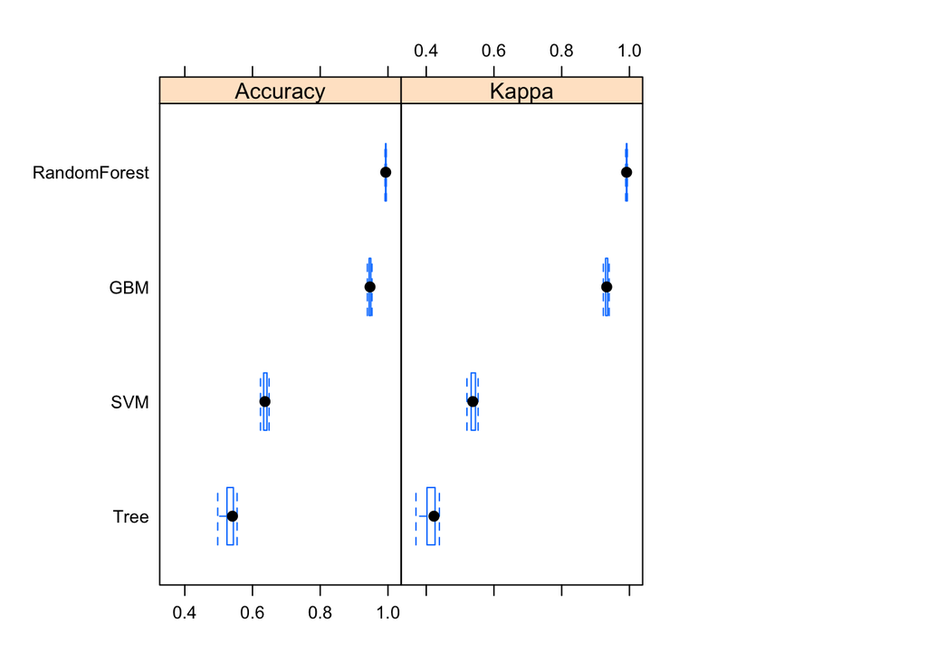

```r
resamps <- resamples(list(Tree = fit_tree,
                          SVM = fit_svm,
                          RandomForest = fit_rf,
                          GBM = fit_gbm))

theme1 <- trellis.par.get()
theme1$plot.symbol$col = rgb(.2, .2, .2, .4)
theme1$plot.symbol$pch = 16
theme1$plot.line$col = rgb(1, 0, 0, .7)
theme1$plot.line$lwd <- 2
trellis.par.set(theme1)
bwplot(resamps, layout = c(3, 1))
```

The high bias encountered with the simpler models (classification tree, linear SVM) suggested a more complex model was required, which is why random forest and stochastic gradient boosting were tried. The improved accuracy of these models was statistically significant:

```r
difValues <- diff(resamps)
summary(difValues)
```

```
##
## Call:
## summary.diff.resamples(object = difValues)
##
## p-value adjustment: bonferroni
## Upper diagonal: estimates of the difference
## Lower diagonal: p-value for H0: difference = 0
##
## Accuracy
##              Tree      SVM       RandomForest GBM
## Tree                   -0.1030   -0.4594      -0.4127
## SVM          < 2.2e-16           -0.3563      -0.3096
## RandomForest < 2.2e-16 < 2.2e-16               0.0467
## GBM          < 2.2e-16 < 2.2e-16 < 2.2e-16
##
## Kappa
##              Tree      SVM       RandomForest GBM
## Tree                   -0.12373  -0.57751     -0.51842
## SVM          < 2.2e-16           -0.45378     -0.39469
## RandomForest < 2.2e-16 < 2.2e-16               0.05909
## GBM          < 2.2e-16 < 2.2e-16 < 2.2e-16
```

## Prediction

```r
predictions <- predict(fit_gbm, newdata = testing)
```